```python
# Data Manipulation and Pre-processing
import pandas as pd
import numpy as np

# Visualizations
import matplotlib.pyplot as plt
import seaborn as sns

# Data Splitting and Timing
from sklearn.model_selection import train_test_split
import time

# Classifiers
from sklearn.neighbors import KNeighborsClassifier
from sklearn.linear_model import LogisticRegression
from sklearn.svm import LinearSVC
from sklearn.svm import SVC
from sklearn.ensemble import RandomForestClassifier, GradientBoostingClassifier, RandomForestRegressor, GradientBoostingRegressor

# Imputers
from sklearn.impute import SimpleImputer
from sklearn.experimental import enable_iterative_imputer
from sklearn.impute import KNNImputer, IterativeImputer

# GridSearch
from sklearn.pipeline import Pipeline
from sklearn.model_selection import GridSearchCV
from sklearn.compose import ColumnTransformer

# Handling Warnings
import warnings
from sklearn.exceptions import ConvergenceWarning
warnings.filterwarnings("ignore", category=ConvergenceWarning)

# Web Interaction and Display
from IPython.display import Image, display, HTML

# Additional JavaScript for toggling code display in Jupyter Notebooks
HTML(
    """
<script src="https://cdnjs.cloudflare.com/ajax/libs/jquery/2.0.3/jquery.min.js "></script>
<script>
code_show=true;
function code_toggle() {
 if (code_show){
 $('div.jp-CodeCell > div.jp-Cell-inputWrapper').hide();
 } else {
 $('div.jp-CodeCell > div.jp-Cell-inputWrapper').show();
 }
 code_show = !code_show
}
$( document ).ready(code_toggle);
</script>
<form action="javascript:code_toggle()"><input type="submit"
    value="Click here to toggle on/off the raw code."></form>
"""
)
```

[figure not shown]

# HIGHLIGHTS

When handling missing values, iterative imputation outperforms single imputation even without hypertuning on validation and holdout sets.

# DATA IS BIASED — SO WHAT?

[figure not shown]

**Figure 1.** A computer program labeled Borden high risk for committing future crimes after stealing a kid's bike. She did not re-offend (Angwin, Larson, Mattu, & Kirchner, 2016).

In 2013, Vernon Prater was arrested for stealing. He previously served five years in prison for armed robbery and attempted armed robbery. The next year, Brisha Borden was arrested for taking a bike. She also has a record, but it was for smaller offenses. Something strange happened when they were booked into jail. An algorithm that predicts if someone will commit future crimes classified Borden, who is black, as high risk; then Prater, who is white, as low risk. Two years later, the algorithm got it all wrong—Borden remained crime-free, while Prater would then serve eight years in prison for stealing thousands of dollars' worth of electronics from a warehouse (Angwin, Larson, Mattu, & Kirchner, 2016).

[figure not shown]

**Figure 2.** News headlines of investigative reports examining the fairness of specific AI applications.

In light of the pervasive integration of AI into decision-making processes, it becomes increasingly crucial to prioritize the fairness of these algorithms. The imperative here is to ensure that these systems remain unbiased and do not discriminate in favor of specific demographic groups, including considerations related to gender, race, or nationality. Upholding fairness in AI is not merely a technological concern but a fundamental ethical principle to prevent unjust disparities and promote equitable outcomes across diverse populations.

[figure not shown]

**Figure 3.** The Different Sources of Downstream Bias in the Machine Learning Pipeline

Concerns about fairness in data aren't new; they've been around long before AI became a big player. It's not simply a matter of dealing with biased data; the quality of how we handle and process this data is equally important. Fairness demands a comprehensive and thoughtful approach to both data itself and the processes that shape its interpretation and utilization.

# UPHOLDING DATA INTEGRITY THROUGH IMPUTATION TECHNIQUES

One major issue about data quality is the presence of missing values. When these gaps exist in the dataset, they can disrupt the seamless flow of data through various processes in the analytical pipeline, such as data visualization. Missing values can also affect the predictive power of machine learning methods. In fact, only a few `scikit-learn` estimators can handle `NaN` values without additional preprocessing. Below is a categorized list of these estimators, organized by type (cluster, regressor, classifier, transformer):

| Cluster | Regressor | Classifier | Transformer |
| --- | --- | --- | --- |
| `HDBSCAN` | `BaggingRegressor` | `BaggingClassifier` | `IterativeImputer` |
|  | `DecisionTreeRegressor` | `DecisionTreeClassifier` | `KNNImputer` |
|  | `HistGradientBoostingRegressor` | `HistGradientBoostingClassifier` | `MaxAbsScaler` |
|  |  |  | `MinMaxScaler` |
|  |  |  | `MissingIndicator` |
|  |  |  | `OneHotEncoder` |
|  |  |  | `OrdinalEncoder` |
|  |  |  | `PowerTransformer` |
|  |  |  | `QuantileTransformer` |
|  |  |  | `RobustScaler` |
|  |  |  | `SimpleImputer` |
|  |  |  | `StandardScaler` |
|  |  |  | `TargetEncoder` |
|  |  |  | `VarianceThreshold` |

**Table 1.** Estimators Capable of Handling Missing (NaN) Values

Enter: Imputation techniques.

There are two ways to handle missing values. The first is the **univariate** method, which uses only one column to fill in the gaps, typically by using statistical measures like the mean or mode. The other is the **multivariate** method, which often employs regression and utilizes the other features in the dataset to predict and fill missing values.

## **The Pitfall of Univarite Imputation: They Do Not Care about the What Ifs**

Single imputations are okay, but they’re not the best mainly because they don’t care about the *what ifs*. For example, if a column has a missing value of 5, single imputation will only replace this with a number, say 3, then that’s it. It doesn’t consider the possibility that the missing value could’ve been any other number.

[figure not shown]

**Figure 4.** Simple Imputation Methods are Naive

But for multiple imputation, not only does it get rid of the missing values, but it also considers the *what ifs*. Pretty cool!

[figure not shown]

**Figure 5.** Multiple Imputation Methods are Iterative

# METHODOLOGY

[figure not shown]

**Figure 6.** The Machine Learning Pipeline

## Data Collection

The dataset was taken from this [GitHub](https://github.com/vshirvaikar/recidivism/tree/main/Data) account. It was released by Vik Shirvaikar and Choudur Lakshminarayan, the authors of the study entitled, “Social Determinants of Recidivism: A Machine Learning Approach”. Only the data from North Carolina was utilized as it was the most comprehensive. However, features are not straightforward; they require additional preprocessing for the desired computations, such as multiplying two columns. Fortunately, the dataset included a guide, albeit in R. Consequently, the final dataset was created using R and exported as a CSV file. The code used for preprocessing in R is attached in the Appendix.

The final dataset contains the following features:

| Feature | Type | Description |
| --- | --- | --- |
| `priors` | integer | Number of past criminal offenses |
| `school` | integer | Years of schooling |
| `violations` | integer | Instances of rule/law violations |
| `age` | float | Age |
| `timeserved` | float | Prison time (Years) |
| `alcohol` | integer | 0 = non-alcoholic and 1 = alcohol problem |
| `drugs` | integer | 0 = non-drug user and 1 = hard drug user |
| `release` | integer | 0 = unsupervised release and 1 = supervised parole |
| `married` | integer | 0 = unmarried and 1 = married |
| `degree` | integer | 0 = misdemeanor and 1 = felony |
| `gender` | integer | 0 = female and 1 = male |
| `type` | integer | Type of crime; includes personal and property crimes, with other crimes as the reference group |
| `property` | integer | 0 = not property-related crime and 1 = property-related crime |
| `person` | integer | 0 = not person-related crime and 1 = person-related crime |
| `recid` | integer | The target variable; 0 = will not commit future crime and 1 = will commit future crime |

**Table 2.** The Final Dataset

To reduce computational time, only 5000 rows were used.

```python
# Load the dataset
df = pd.read_csv('output.csv')

# Randomly sample 5000 rows
df_sample = df.sample(n=5000, random_state=42).reset_index(drop=True)
```

## Exploratory Data Analysis

### Descriptive Statistics

We note that the `age` variable has the highest variability compared to the other features. It also has the greater spread based on the difference between its minimum and maximum values.

```python
df_sample.describe()
```

|  | priors | school | violations | age | timeserved | alcohol | drugs | release | married | degree | gender | type | property | person | recid |
| --- | --- | --- | --- | --- | --- | --- | --- | --- | --- | --- | --- | --- | --- | --- | --- |
| count | 5000.000000 | 5000.000000 | 5000.000000 | 5000.000000 | 5000.000000 | 5000.000000 | 5000.000000 | 5000.000000 | 5000.000000 | 5000.000000 | 5000.000000 | 5000.000000 | 5000.000000 | 5000.000000 | 5000.000000 |
| mean | 1.362600 | 9.613200 | 1.329000 | 28.598767 | 1.598650 | 0.282200 | 0.230400 | 0.757200 | 0.247600 | 0.369000 | 0.940400 | 0.794000 | 0.353400 | 0.087200 | 0.382200 |
| std | 2.749151 | 2.385105 | 2.824032 | 9.814347 | 1.782309 | 0.450115 | 0.421131 | 0.428818 | 0.431661 | 0.482582 | 0.236768 | 0.933026 | 0.478073 | 0.282156 | 0.485974 |
| min | 0.000000 | 1.000000 | 0.000000 | 15.750000 | 0.083333 | 0.000000 | 0.000000 | 0.000000 | 0.000000 | 0.000000 | 0.000000 | 0.000000 | 0.000000 | 0.000000 | 0.000000 |
| 25% | 0.000000 | 8.000000 | 0.000000 | 21.416667 | 0.500000 | 0.000000 | 0.000000 | 1.000000 | 0.000000 | 0.000000 | 1.000000 | 0.000000 | 0.000000 | 0.000000 | 0.000000 |
| 50% | 0.000000 | 10.000000 | 0.000000 | 25.666667 | 1.000000 | 0.000000 | 0.000000 | 1.000000 | 0.000000 | 0.000000 | 1.000000 | 0.000000 | 0.000000 | 0.000000 | 0.000000 |
| 75% | 2.000000 | 11.000000 | 1.000000 | 32.750000 | 2.166667 | 1.000000 | 0.000000 | 1.000000 | 0.000000 | 1.000000 | 1.000000 | 2.000000 | 1.000000 | 0.000000 | 1.000000 |
| max | 40.000000 | 19.000000 | 39.000000 | 76.583333 | 22.750000 | 1.000000 | 1.000000 | 1.000000 | 1.000000 | 1.000000 | 1.000000 | 2.000000 | 1.000000 | 1.000000 | 1.000000 |

### Check for Imbalance

Referring to this [guide](https://developers.google.com/machine-learning/data-prep/construct/sampling-splitting/imbalanced-data?fbclid=IwAR0vUyfQIeGdX-d7fxXcJEUSHzeC65tKetLr9Kme9TtitJayATqLw8zu-TQ), our target variable recid exhibits only a slight imbalance. Thus, applying a sampling technique may offer limited benefits given the relatively modest imbalance in the data.

```
Class Proportions for the Target Variable:
recid
0    0.6178
1    0.3822
Name: count, dtype: float64
```

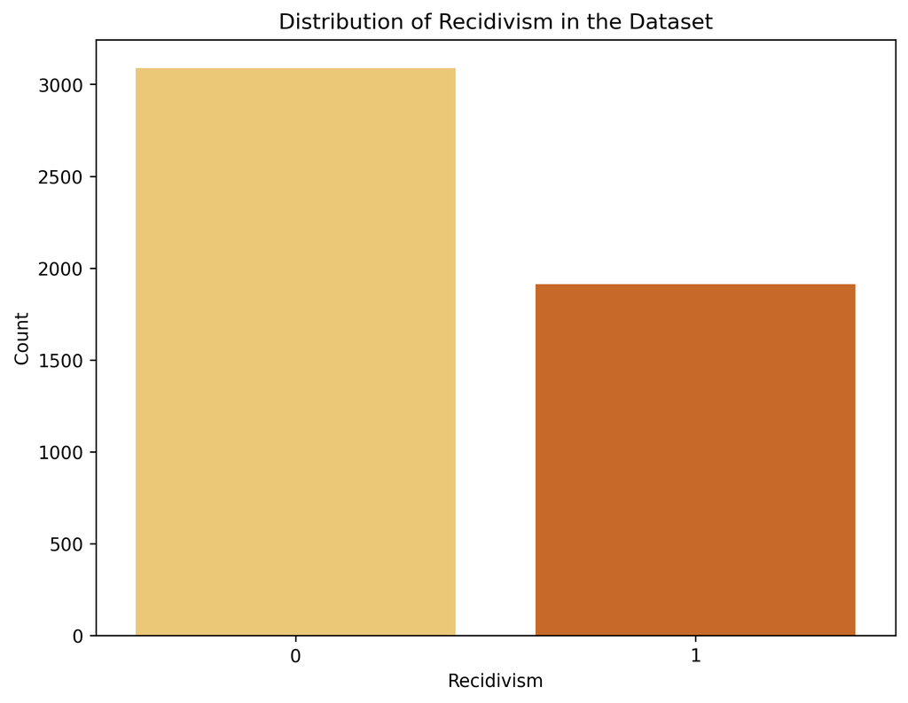

```python
# Display the proportion of each class in the target variable
print("Class Proportions for the Target Variable:")
class_proportions = df_sample.recid.value_counts() / len(df_sample)
print(class_proportions)

# Plot the distribution of the target variable
plt.figure(figsize=(8, 6), dpi=250)
sns.countplot(x='recid', data=df_sample, palette='YlOrBr')
plt.xlabel('Recidivism')
plt.ylabel('Count')
plt.title('Distribution of Recidivism in the Dataset')
plt.show()
```

**Figure 7.** The Distribution of the Target Variable in the Dataset

### Proportional Chance Criterion

```python
X_sample, y_sample = (df_sample.drop(['type', 'recid'], axis=1),
                      df_sample['recid'])
pcc = ((y_sample.value_counts() / len(y_sample)) ** 2).sum()
desired_accuracy = 1.25 * pcc
print(f"PCC: {pcc:.4f}")
print(f"Heuristic: {desired_accuracy:.4f}")
```

```
PCC: 0.5278
Heuristic: 0.6597
```

### Correlation Heat Map

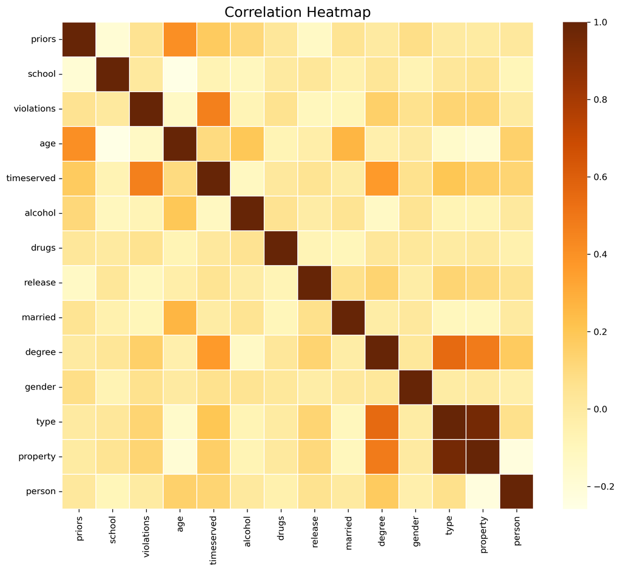

```python
columns_to_plot = ['priors', 'school', 'violations', 'age', 'timeserved',
                   'alcohol', 'drugs', 'release', 'married', 'degree',
                   'gender', 'type', 'property', 'person']

# Calculate the correlation matrix
correlation_matrix = df_sample[columns_to_plot].corr()

# Set the size of the figure
plt.figure(figsize=(12, 10), dpi=300)

# Create a heatmap
sns.heatmap(correlation_matrix, annot=False, cmap='YlOrBr', fmt=".2f",
            linewidths=.5)

plt.title("Correlation Heatmap", fontsize=16)
plt.show()
```

**Figure 8.** Correlation Plot of Each Feature in the Dataset

## Creation of Artificial Missing Values

```python
# Set a random seed for reproducibility
rng = np.random.RandomState(42)

# Create copies of the original dataset as NumPy arrays
X_missing = X_sample.copy().to_numpy()
y_missing = y_sample.copy().to_numpy()

# Get the number of samples and features in the dataset
n_samples, n_features = X_missing.shape

# Define the missing rate (percentage of lines with missing values)
missing_rate = 0.75

# Calculate the number of samples with missing values
n_missing_samples = int(n_samples * missing_rate)

# Create a boolean array to identify which samples will have missing values
missing_samples = np.zeros(n_samples, dtype=bool)
missing_samples[:n_missing_samples] = True

# Shuffle the array to randomly distribute missing values across samples
rng.shuffle(missing_samples)

# Generate random indices for features with missing values
missing_features = rng.randint(0, n_features, n_missing_samples)

# Introduce missing values into the dataset
X_missing[missing_samples, missing_features] = np.nan

# Get the column names from the original dataset
columns = X_sample.columns.tolist()

# Create a new DataFrame with missing values
df_with_missing = pd.DataFrame(data=np.hstack(
    (X_missing, y_missing.reshape(-1, 1))), columns=columns + ['recid'])
```

Note that the dataset used is complete (no missing values), so we have to introduce artificial missing values to demonstrate the functionality of the imputation techniques.

Here are the first five rows of the dataframe with artificial missing values:

```python
df_with_missing.head(5)
```

|  | priors | school | violations | age | timeserved | alcohol | drugs | release | married | degree | gender | property | person | recid |
| --- | --- | --- | --- | --- | --- | --- | --- | --- | --- | --- | --- | --- | --- | --- |
| 0 | 0.0 | 10.0 | 1.0 | 20.416667 | 1.000000 | 0.0 | 0.0 | 0.0 | 0.0 | NaN | 1.0 | 0.0 | 0.0 | 1.0 |
| 1 | 0.0 | 11.0 | NaN | 20.833333 | 2.250000 | 1.0 | 1.0 | 1.0 | 0.0 | 0.0 | 1.0 | 0.0 | 0.0 | 1.0 |
| 2 | 0.0 | 10.0 | 22.0 | 20.500000 | 6.333333 | 0.0 | 0.0 | 1.0 | 0.0 | 1.0 | NaN | 0.0 | 1.0 | 1.0 |
| 3 | 5.0 | 14.0 | 2.0 | 35.416667 | 0.500000 | 0.0 | NaN | 1.0 | 0.0 | 0.0 | 1.0 | 0.0 | 0.0 | 0.0 |
| 4 | 8.0 | 12.0 | 3.0 | 34.083333 | 5.166667 | 0.0 | 1.0 | 0.0 | 0.0 | 1.0 | NaN | 1.0 | 0.0 | 0.0 |

## Missing Value Imputation

### Univariate Imputation using the Mean and Mode

For single imputation, we simply take the `mean` of columns with numeric values, then the `mode` of columns with categorical values.

```python
# Impute values for the numeric and categorical columns using mean and mode, respectively
# Create a copy of the DataFrame that needs imputation
df_single_imputed = df_with_missing.copy()

# Identify columns for mean and mode imputation
cols_mean_imputed = df_with_missing.columns[:5]
cols_mode_imputed = df_with_missing.columns[5:-1]

# Impute missing values with mean for specified columns
mean_imputer = SimpleImputer(strategy='mean')
df_single_imputed[cols_mean_imputed] = mean_imputer.fit_transform(
    df_single_imputed[cols_mean_imputed])

# Impute missing values with mode for specified columns
mode_imputer = SimpleImputer(strategy='most_frequent')
df_single_imputed[cols_mode_imputed] = mode_imputer.fit_transform(
    df_single_imputed[cols_mode_imputed])

# Create a train_test_split using this dataframe with single imputations
X_simple, y_simple = (df_single_imputed.drop(['recid'], axis=1),
                      df_single_imputed['recid'])
X_trainval_simp, X_holdout_simp, y_trainval_simp, y_holdout_simp = train_test_split(
    X_simple, y_simple, test_size=0.20, random_state=42)
```

Here are the first five rows of the dataframe that used single imputation:

```python
df_single_imputed.head(5)
```

|  | priors | school | violations | age | timeserved | alcohol | drugs | release | married | degree | gender | property | person | recid |
| --- | --- | --- | --- | --- | --- | --- | --- | --- | --- | --- | --- | --- | --- | --- |
| 0 | 0.0 | 10.0 | 1.000000 | 20.416667 | 1.000000 | 0.0 | 0.0 | 0.0 | 0.0 | 0.0 | 1.0 | 0.0 | 0.0 | 1.0 |
| 1 | 0.0 | 11.0 | 1.334464 | 20.833333 | 2.250000 | 1.0 | 1.0 | 1.0 | 0.0 | 0.0 | 1.0 | 0.0 | 0.0 | 1.0 |
| 2 | 0.0 | 10.0 | 22.000000 | 20.500000 | 6.333333 | 0.0 | 0.0 | 1.0 | 0.0 | 1.0 | 1.0 | 0.0 | 1.0 | 1.0 |
| 3 | 5.0 | 14.0 | 2.000000 | 35.416667 | 0.500000 | 0.0 | 0.0 | 1.0 | 0.0 | 0.0 | 1.0 | 0.0 | 0.0 | 0.0 |
| 4 | 8.0 | 12.0 | 3.000000 | 34.083333 | 5.166667 | 0.0 | 1.0 | 0.0 | 0.0 | 1.0 | 1.0 | 1.0 | 0.0 | 0.0 |

### Multivariate Imputation using `sklearn`'s `KNNImputer` and `IterativeImputer`

```python
# Separate into trainval and holdout
X, y = df_with_missing.drop("recid", axis=1), df_with_missing["recid"]
X_trainval_multi, X_holdout_multi, y_trainval_multi, y_holdout_multi = train_test_split(
    X, y, test_size=0.20, random_state=42
)

# What are the categorical variables in the dataset?
knn_cols = [df_with_missing.columns[3]] + df_with_missing.columns[5:-1].tolist()

# What are the numerical variables in the dataset?
iterative_cols = df_with_missing.columns[:3].tolist() + [df_with_missing.columns[4]]
```

# MACHINE LEARNING CLASSIFICATION

Let's use `GridSearch` to find the best machine learning classification for each type of imputation

## Grid Search Using Univariate Imputation

```python
# Default parameters
# List of classifiers
classifiers = [
    LogisticRegression(),
    LinearSVC(),
    KNeighborsClassifier(),
    RandomForestClassifier(),
    GradientBoostingClassifier(),
]

# Define the parameter grid with different penalty values for LinearSVC
param_grid = [{'clf': [LinearSVC()], 'clf__penalty': ['l1', 'l2'], 'clf__loss': ['hinge', 'squared_hinge'],
               'clf__max_iter': [1000], 'clf__tol': [0.01], 'clf__dual': ['auto']},
              {'clf': classifiers}]

# Create the pipeline
steps = [('clf', None)]
pipeline = Pipeline(steps)

# Create GridSearchCV
grid_search_simple = GridSearchCV(pipeline, param_grid, cv=5, scoring='accuracy',
                           n_jobs=-1, verbose=0, return_train_score=True)  # Adjust cv and scoring as needed

# Fit the grid search to your data
grid_search_simple.fit(X_trainval_simp, y_trainval_simp)
```

[output not shown]

[output cut: 46 more lines]

[output not shown]

```
GridSearchCV(cv=5, estimator=Pipeline(steps=[('clf', None)]), n_jobs=-1,
             param_grid=[{'clf': [LinearSVC()], 'clf__dual': ['auto'],
                          'clf__loss': ['hinge', 'squared_hinge'],
                          'clf__max_iter': [1000], 'clf__penalty': ['l1', 'l2'],
                          'clf__tol': [0.01]},
                         {'clf': [LogisticRegression(), LinearSVC(),
                                  KNeighborsClassifier(),
                                  RandomForestClassifier(),
                                  GradientBoostingClassifier()]}],
             return_train_score=True, scoring='accuracy')
```

## Grid Search Using Multivariate Imputation

```python
# Default parameters
# List of classifiers
classifiers = [
    LogisticRegression(),
    LinearSVC(),
    KNeighborsClassifier(),
    RandomForestClassifier(),
    GradientBoostingClassifier(),
]

# Define the parameter grid with different penalty values for LinearSVC
param_grid = [{'clf': [LinearSVC()], 'clf__penalty': ['l1', 'l2'], 'clf__loss': ['hinge', 'squared_hinge'],
               'clf__max_iter': [1000], 'clf__tol': [0.01], 'clf__dual': ['auto']},
              {'clf': classifiers}]

# Specify the parameters you want to search in the grid for imputer
param_grid_imputer = {
    'imputer__knn__n_neighbors': [4, 5],
    'imputer__iterative__estimator__max_depth': [4],
    'imputer__iterative__estimator__max_features': [0.5, 0.7, 0.8],
    'imputer__iterative__estimator__learning_rate': [0.1, 0.5, 1.],
    'imputer__iterative__tol': [0.1],
}

# Combine the parameter grids
param_grid_combined = [{**param1, **param2} for param1 in param_grid for param2 in [param_grid_imputer]]

# Create the column transformer
preprocessor = ColumnTransformer(
    transformers=[
        ('knn', KNNImputer(), knn_cols),
        ('iterative', IterativeImputer(estimator=GradientBoostingRegressor()), iterative_cols),
        # You can add more transformers for other columns if needed
    ])

# Create the final pipeline with the column transformer and classifier
pipeline = Pipeline([
    ('imputer', preprocessor),
    ('clf', GradientBoostingClassifier())
    # Add other steps in the pipeline if needed
])

# Create GridSearchCV
grid_search = GridSearchCV(pipeline, param_grid_combined, cv=5,
                           scoring='accuracy', n_jobs=-1, verbose=True, return_train_score=True)

# Fit the grid search to your data
grid_search.fit(X_trainval_multi, y_trainval_multi)
```

```
Fitting 5 folds for each of 162 candidates, totalling 810 fits
```

[output not shown]

[output cut: 2271 more lines]

[output not shown]

```
GridSearchCV(cv=5,
             estimator=Pipeline(steps=[('imputer',
                                        ColumnTransformer(transformers=[('knn',
                                                                         KNNImputer(),
                                                                         ['age',
                                                                          'alcohol',
                                                                          'drugs',
                                                                          'release',
                                                                          'married',
                                                                          'degree',
                                                                          'gender',
                                                                          'property',
                                                                          'person']),
                                                                        ('iterative',
                                                                         IterativeImputer(estimator=GradientBoostingRegressor()),
                                                                         ['priors',
                                                                          'school',
                                                                          'violations',
                                                                          'timeserved'])])),
                                       ('clf', GradientBoostingClassifier())]),...
                                  KNeighborsClassifier(),
                                  RandomForestClassifier(),
                                  GradientBoostingClassifier()],
                          'imputer__iterative__estimator__learning_rate': [0.1,
                                                                           0.5,
                                                                           1.0],
                          'imputer__iterative__estimator__max_depth': [4],
                          'imputer__iterative__estimator__max_features': [0.5,
                                                                          0.7,
                                                                          0.8],
                          'imputer__iterative__tol': [0.1],
                          'imputer__knn__n_neighbors': [4, 5]}],
             return_train_score=True, scoring='accuracy', verbose=True)
```

# RESULTS AND DISCUSSION

## Univariate Imputation

```python
# Access the best model from the grid search
best_model_simple = grid_search_simple.best_estimator_

# Print the best model
print(f"The best model is: {grid_search_simple.best_params_['clf']}")
print(f"With an accuracy of: {grid_search_simple.best_score_:.6f}")

top3_predictors_simple = X_trainval_simp.columns[best_model_simple.named_steps['clf'].feature_importances_.argsort()[-3:][::-1]].values.tolist()
print("Top predictors:", top3_predictors_simple)
```

```
The best model is: GradientBoostingClassifier()
With an accuracy of: 0.649750
Top predictors: ['age', 'priors', 'timeserved']
```

Here is the performance of the other classification models on the `trainval` set:

```python
# Assuming you have cv_results as a DataFrame
cv_results_df_simple = pd.DataFrame(grid_search_simple.cv_results_)

# Extract relevant columns
relevant_columns = ['param_clf', 'mean_test_score', 'std_test_score', 'mean_fit_time',]

# Create a DataFrame with relevant information
results_df_simple = cv_results_df_simple[relevant_columns].copy()

# Sort the DataFrame by mean_test_score
results_df_simple = results_df_simple.sort_values(by='mean_test_score', ascending=False).reset_index(drop=True)
results_df_simple = results_df_simple.drop_duplicates(subset='param_clf', keep='first')

# Print or analyze the results DataFrame as needed
results_df_simple.dropna(axis=0, inplace=True)
results_df_simple.columns = [['Classifier', 'Mean Validation Score', 'Std Test Score', 'Mean Fit Time',]]
results_df_simple
```

|  | Classifier | Mean Validation Score | Std Test Score | Mean Fit Time |
| --- | --- | --- | --- | --- |
| 0 | GradientBoostingClassifier() | 0.64975 | 0.015317 | 0.346018 |
| 1 | LogisticRegression() | 0.64900 | 0.015379 | 0.060517 |
| 2 | LinearSVC(dual='auto', tol=0.01) | 0.64675 | 0.013684 | 0.015292 |
| 3 | RandomForestClassifier() | 0.63225 | 0.025780 | 0.451471 |
| 4 | KNeighborsClassifier() | 0.60175 | 0.021903 | 0.006820 |
| 5 | LinearSVC() | 0.53250 | 0.101760 | 0.213507 |

Now, using the best estimator (GBM) to predict `X_holdout_simp` and `y_holdout_simp`, we get a test accuracy of 67.3%. Again, it peforms better than random chance (65.97%), as well as against the validation set (64.98%).

```python
best_model_score_simple = grid_search_simple.best_estimator_.score(X_holdout_simp, y_holdout_simp)
print(f"The score of the best model ({grid_search_simple.best_params_['clf']}) is: {best_model_score_simple}")
```

```
The score of the best model (GradientBoostingClassifier()) is: 0.673
```

## Multivariate Imputation

```python
# Access the best model from the grid search
best_model_iter = grid_search.best_estimator_

# Print the best model
print(f"The best model is: {grid_search.best_params_['clf']}")
print(f"With an accuracy of: {grid_search.best_score_:.6f}")

top3_predictors_iter = X_trainval_multi.columns[best_model_iter.named_steps['clf'].feature_importances_.argsort()[-3:][::-1]].values.tolist()
print("Top predictors:", top3_predictors_iter)
```

```
The best model is: GradientBoostingClassifier()
With an accuracy of: 0.662750
Top predictors: ['priors', 'degree', 'person']
```

Here is the performance of the other classification models on the `trainval` set:

```python
cv_results_iter = pd.DataFrame(grid_search.__dict__['cv_results_'])

# Assuming you have cv_results as a DataFrame
cv_results_df_iter = pd.DataFrame(grid_search.cv_results_)

# Extract relevant columns
relevant_columns = ['param_clf', 'mean_test_score', 'std_test_score', 'mean_fit_time']

# Create a DataFrame with relevant information
results_df_iter = cv_results_df_iter[relevant_columns].copy()


# Sort the DataFrame by mean_test_score
results_df_iter = results_df_iter.sort_values(by='mean_test_score', ascending=False).reset_index(drop=True)
results_df_iter = results_df_iter.drop_duplicates(subset='param_clf', keep='first')

# Print or analyze the results DataFrame as needed
results_df_iter.dropna(axis=0, inplace=True)
results_df_iter.columns = ['Classifier', 'Mean Validation Score', 'Std Test Score', 'Mean Fit Time',]
results_df_iter
```

|  | Classifier | Mean Validation Score | Std Test Score | Mean Fit Time |
| --- | --- | --- | --- | --- |
| 0 | GradientBoostingClassifier() | 0.66275 | 0.014085 | 2.361565 |
| 18 | LogisticRegression() | 0.65200 | 0.008314 | 1.670178 |
| 27 | LinearSVC() | 0.64925 | 0.009925 | 1.489562 |
| 72 | RandomForestClassifier() | 0.63925 | 0.015342 | 2.035490 |
| 78 | LinearSVC() | 0.63025 | 0.010410 | 2.263078 |
| 103 | KNeighborsClassifier() | 0.61750 | 0.020264 | 4.236152 |

Using the best estimator (GBM) to predict `X_holdout_multi` and `y_holdout_multi`, we get a test accuracy of 68.2%. This is higher than the test accuracy using simple imputation (67.3%) and random heuristic (65.97%).

```python
best_model_score_multi = grid_search.best_estimator_.score(X_holdout_multi, y_holdout_multi)
print(f"The score of the best model ({grid_search.best_params_['clf']}) is: {best_model_score_multi}")
```

```
The score of the best model (GradientBoostingClassifier()) is: 0.682
```

# CONCLUSION AND RECOMMENDATIONS

From our results, we see that GBM outperformed other algorithms in both imputation methods. While the presented numbers may not be visually appealing, note that only the default parameters were used during modeling. This ensures that any observed improvements in accuracy can be directly attributed to the imputation techniques.

Despite the modest appearance of the results, there is notable improvement in accuracy, especially for SVM L1. Just imagine the possible results if we were to hypertune the classifiers and imputers. This holds the promise of further refining the models and potentially achieving even more impressive results.

## The Need for Hypertuning

Moving forward, it is imperative to conduct thorough hyperparameter tuning for both classifiers and imputers. This optimization will allow the models to reach their full potential and enhance their accuracy and robustness. Additionally, consider expanding the dataset through either feature engineering techniques or acquiring more data. A larger and more diverse dataset can provide the models with a richer set of patterns to learn from, which will further improve their performance.

## Explore Non-regression Estimators

In terms of imputation strategies, exploring non-regression algorithms as estimators for iterative imputers could offer valuable insights. Iterative imputation methods, when coupled with suitable estimators, can be powerful tools for handling missing data effectively. This approach may uncover intricate relationships within the data and contribute to more accurate imputations.

## The Long-run Game

Lastly, integrating unsupervised learning techniques into the model can be beneficial. Unsupervised learning can unveil hidden patterns and clusters within the data, which could provide a more comprehensive understanding of the underlying dynamics related to recidivism. This aligns with the broader goal that extends from merely classifying re-offenders to identifying the determinants of recidivism, which is important to build a system that prioritizes rehabilitation and reintegration of individuals into society.

# APPENDIX

## Getting the final dataset using R

```
### ICPSR North Carolina Dataset

# I. Read the dataset and pull out usable columns.

reader = file("northcarolina1.txt", open = "r")
input = readLines(reader)
close(reader)
data = matrix(, nrow = 0, ncol = 28)
for(line in input){
  line = strtoi(strsplit(line, split = "")[[1]])
  if(line[28] != 3){
    data = rbind(data, line[1:28])
  }
}
reader = file("northcarolina2.txt", open = "r")
input = readLines(reader)
close(reader)
for(line in input){
  line = strtoi(strsplit(line, split = "")[[1]])
  if(line[28] != 3){
    data = rbind(data, line[1:28])
  }
}
data[is.na(data)] = 0
priors = 10*data[,11] + data[,12]
school = 10*data[,13] + data[,14]
violations = 10*data[,15] + data[,16]
age = (100*data[,17] + 10*data[,18] + data[,19])/12
timeserved = (100*data[,20] + 10*data[,21] + data[,22])/12
alcohol = data[,2]
# non-alcoholic = 0 and alcohol problem = 1
drugs = data[,3]
# non-drug user = 0 and hard drug user = 1
release = data[,4]
# unsupervised release = 0 and supervised parole = 1
married = data[,5]
# unmarried = 0 and married = 1
degree = data[,6]
# misdemeanor = 0 and felony = 1
gender = data[,10]
# female = 0 and male = 1
type = data[,8]*2 + data[,9]
typeR = data[, 8:9]
colnames(typeR) = c("property", "person")
# sets "other" as reference
recid = data[,25]

# Create a dataframe with the variables
df <- data.frame(
  priors = priors,
  school = school,
  violations = violations,
  age = age,
  timeserved = timeserved,
  alcohol = alcohol,
  drugs = drugs,
  release = release,
  married = married,
  degree = degree,
  gender = gender,
  type = type,
  property = typeR[, "property"],
  person = typeR[, "person"],
  recid = recid
)

# Display the first few rows of the dataframe
head(df)

# Export to CSV
write.csv(df, file = "output.csv", row.names = FALSE)
```

```python
# Separate into trainval and holdout
X, y = df_with_missing.drop("recid", axis=1), df_with_missing["recid"]
X_trainval_multi, X_holdout_multi, y_trainval_multi, y_holdout_multi = train_test_split(
    X, y, test_size=0.20, random_state=42
)

# What are the categorical variables in the dataset?
knn_cols_2 = df_with_missing.columns[5:-1]

# What are the numerical variables in the dataset?
iterative_cols_2 = df_with_missing.columns[:5]
```

```python
# Default parameters
# List of classifiers
classifiers = [
    LogisticRegression(),
    LinearSVC(),
    KNeighborsClassifier(),
    RandomForestClassifier(),
    GradientBoostingClassifier(),
]

# Define the parameter grid with different penalty values for LinearSVC
param_grid = [{'clf': [LinearSVC()], 'clf__penalty': ['l1', 'l2'], 'clf__loss': ['hinge', 'squared_hinge'],
               'clf__max_iter': [1000], 'clf__tol': [0.01], 'clf__dual': ['auto']},
              {'clf': classifiers}]

# Specify the parameters you want to search in the grid for imputer
param_grid_imputer = {
    'imputer__knn__n_neighbors': [4, 5],
    'imputer__iterative__estimator__max_depth': [4],
    'imputer__iterative__estimator__max_features': [0.5, 0.7, 0.8],
    'imputer__iterative__estimator__learning_rate': [0.1, 0.5, 1.],
    'imputer__iterative__tol': [0.1],
}

# Combine the parameter grids
param_grid_combined = [{**param1, **param2} for param1 in param_grid for param2 in [param_grid_imputer]]

# Create the column transformer
preprocessor = ColumnTransformer(
    transformers=[
        ('knn', KNNImputer(), knn_cols),
        ('iterative', IterativeImputer(estimator=GradientBoostingRegressor()), iterative_cols),
        # You can add more transformers for other columns if needed
    ])

# Create the final pipeline with the column transformer and classifier
pipeline = Pipeline([
    ('imputer', preprocessor),
    ('clf', GradientBoostingClassifier())
    # Add other steps in the pipeline if needed
])

# Create GridSearchCV
grid_search = GridSearchCV(pipeline, param_grid_combined, cv=5,
                           scoring='accuracy', n_jobs=-1, verbose=True, return_train_score=True)

# Fit the grid search to your data
grid_search.fit(X_trainval_multi, y_trainval_multi)
```

```
Fitting 5 folds for each of 162 candidates, totalling 810 fits
```

[output not shown]

[output cut: 2275 more lines]

[output not shown]

```
GridSearchCV(cv=5,
             estimator=Pipeline(steps=[('imputer',
                                        ColumnTransformer(transformers=[('knn',
                                                                         KNNImputer(),
                                                                         ['age',
                                                                          'alcohol',
                                                                          'drugs',
                                                                          'release',
                                                                          'married',
                                                                          'degree',
                                                                          'gender',
                                                                          'property',
                                                                          'person']),
                                                                        ('iterative',
                                                                         IterativeImputer(estimator=GradientBoostingRegressor()),
                                                                         ['priors',
                                                                          'school',
                                                                          'violations',
                                                                          'timeserved'])])),
                                       ('clf', GradientBoostingClassifier())]),...
                                  KNeighborsClassifier(),
                                  RandomForestClassifier(),
                                  GradientBoostingClassifier()],
                          'imputer__iterative__estimator__learning_rate': [0.1,
                                                                           0.5,
                                                                           1.0],
                          'imputer__iterative__estimator__max_depth': [4],
                          'imputer__iterative__estimator__max_features': [0.5,
                                                                          0.7,
                                                                          0.8],
                          'imputer__iterative__tol': [0.1],
                          'imputer__knn__n_neighbors': [4, 5]}],
             return_train_score=True, scoring='accuracy', verbose=True)
```

```python
# Access the best model from the grid search
best_model_iter = grid_search.best_estimator_

# Print the best model
print(f"The best model is: {grid_search.best_params_['clf']}")
print(f"With an accuracy of: {grid_search.best_score_:.6f}")

top3_predictors_iter = X_trainval_multi.columns[best_model_iter.named_steps['clf'].feature_importances_.argsort()[-3:][::-1]].values.tolist()
print("Top predictors:", top3_predictors_iter)
```

```
The best model is: GradientBoostingClassifier()
With an accuracy of: 0.662500
Top predictors: ['priors', 'degree', 'person']
```

Here is the performance of the other classification models on the `trainval` set:

```python
cv_results_iter = pd.DataFrame(grid_search.__dict__['cv_results_'])

# Assuming you have cv_results as a DataFrame
cv_results_df_iter = pd.DataFrame(grid_search.cv_results_)

# Extract relevant columns
relevant_columns = ['param_clf', 'mean_test_score', 'std_test_score', 'mean_fit_time']

# Create a DataFrame with relevant information
results_df_iter = cv_results_df_iter[relevant_columns].copy()


# Sort the DataFrame by mean_test_score
results_df_iter = results_df_iter.sort_values(by='mean_test_score', ascending=False).reset_index(drop=True)
results_df_iter = results_df_iter.drop_duplicates(subset='param_clf', keep='first')

# Print or analyze the results DataFrame as needed
results_df_iter.dropna(axis=0, inplace=True)
results_df_iter.columns = ['Classifier', 'Mean Validation Score', 'Std Test Score', 'Mean Fit Time',]
results_df_iter
```

|  | Classifier | Mean Validation Score | Std Test Score | Mean Fit Time |
| --- | --- | --- | --- | --- |
| 0 | GradientBoostingClassifier() | 0.66250 | 0.019284 | 5.184454 |
| 17 | LogisticRegression() | 0.65175 | 0.009341 | 1.520927 |
| 28 | LinearSVC() | 0.64950 | 0.010296 | 4.476197 |
| 72 | RandomForestClassifier() | 0.63625 | 0.014383 | 5.284147 |
| 88 | LinearSVC() | 0.62650 | 0.007722 | 6.439311 |
| 105 | KNeighborsClassifier() | 0.61750 | 0.014470 | 4.746970 |

```python
best_model_score_multi = grid_search.best_estimator_.score(X_holdout_multi, y_holdout_multi)
print(f"The score of the best model ({grid_search.best_params_['clf']}) is: {best_model_score_multi}")
```

```
The score of the best model (GradientBoostingClassifier()) is: 0.674
```

# REFERENCES

Angwin, J., Larson, J., Mattu, S., & Kirchner, L. (2016, May 23). Machine bias. ProPublica. https://www.propublica.org/article/machine-bias-risk-assessments-in-criminal-sentencing

Black loans matter: Fighting bias for AI fairness in lending. (2020, October 22). MIT-IBM Watson AI Lab. https://mitibmwatsonailab.mit.edu/black-loans-matter-fighting-bias-for-ai-fairness-in-lending/

Hoque, G. (2020, December 8). A better way to handle missing values in your dataset: Using IterativeImputer (PART I). Towards Data Science. https://towardsdatascience.com/a-better-way-to-handle-missing-values-in-your-dataset-using-iterativeimputer-part-i-9c4f7f0f6a0

Introducing the AI Alliance. (n.d.). Meta. Retrieved December 3, 2023, from https://www.meta.com/ai-alliance

IterativeImputer. (n.d.). Scikit-learn. Retrieved December 3, 2023, from https://scikit-learn.org/stable/modules/generated/sklearn.impute.IterativeImputer.html

Kehl, D. L., & Kessler, S. A. (2017). Algorithms in the criminal justice system: Assessing the use of risk assessments in sentencing. Berkman Klein Center for Internet & Society. https://dash.harvard.edu/bitstream/handle/1/33746041/2017-07_responsivecommunities_2.pdf

KNNImputer. (n.d.). Scikit-learn. Retrieved December 3, 2023, from https://scikit-learn.org/stable/modules/generated/sklearn.impute.KNNImputer.html

Mittelstadt, B., Russell, C., & Wachter, S. (2019). Algorithmic fairness in artificial intelligence for medicine and healthcare. Nature Biomedical Engineering, 3(6), 405–409. https://doi.org/10.1038/s41551-019-0405-1

Suresh, H., & Guttag, J. (2021). A framework for understanding sources of harm throughout the machine learning life cycle. Equity and Access in Algorithms, Mechanisms, and Optimization. https://arxiv.org/abs/2103.07551

Testing FATE: Is AI fair in higher education? (2021, October 14). SFU Research. https://www.sfu.ca/research/stories/2021/10/testing-fate-is-ai-fair-in-higher-education.html